# ciber

目前主流的免疫浸润计算方法是CIBERSORT和ssgsea，今天介绍CIBERSORT。

### 1.输入数据要什么

下面这段话摘自CIBERSORT的介绍

> Importantly, all expression data should be non-negative, devoid of missing values, and represented in non-log linear space.

> For Affymetrix microarrays, a custom chip definition file (CDF) is recommended (see Subheading 3.2.2) and should be normalized with MAS5 or RMA.

> Illumina Beadchip and single color Agilent arrays should be processed as described in the limma package.

> Standard RNA-Seq expression quantification metrics, such as frag- ments per kilobase per million (FPKM) and transcripts per kilobase million (TPM), are suitable for use with CIBERSORT. –《Profiling Tumor Infiltrating Immune Cells with CIBERSORT》

非常清楚的写出了输入数据的要求： 1.不可以有负值和缺失值 2.不要取log 3.如果是芯片数据，昂飞芯片使用RMA标准化，Illumina 的Beadchip 和Agilent的单色芯片，用limma处理。 4.如果是RNA-Seq表达量，使用FPKM和TPM都很合适。

芯片的要求可能把你唬住了，GEO常规的表达矩阵都是这样得到的，直接下载使用即可。注意有的表达矩阵下载下来就已经取过log，需要逆转回去。有的经过了标准化或者有负值，需要处理原始数据，前面写过介绍文了。

### 3.来一个示例

```r
rm(list = ls())
library(tidyverse)
load("../4_tcga_model/TCGA-STAD_sur_model.Rdata")
```

#### 3.3 做成cibersort要求的输入文件

需要两个输入文件:

一个是表达矩阵文件

一个是R包内置的数据LM22.txt，记录了22种免疫细胞的基因表达特征数据。

由于CIBERSORT读取文件的代码比较粗暴，为了适应它，导出文件之前需要把行名变成一列。不然后面就会有报错。

```r
library(tidyverse)
exp = exprSet
exp2 = as.data.frame(exp)
exp2 = rownames_to_column(exp2)
write.table(exp2,file = "exp.txt",row.names = F,quote = F,sep = "\t")
```

#### 3.4. 运行CIBERSORT

```r
f = "ciber_STAD.Rdata"
if(!file.exists(f)){
  #devtools:: install_github ("Moonerss/CIBERSORT")
  library(CIBERSORT)
  lm22f = system.file("extdata", "LM22.txt", package = "CIBERSORT")
  TME.results = cibersort(lm22f,
                        "exp.txt" ,
                        perm = 1000,
                        QN = T)
  save(TME.results,file = f)
}
load(f)
TME.results[1:4,1:4]
```

```
##                  B cells naive B cells memory Plasma cells
## TCGA-CG-5722-01A    0.02654326     0.01753894   0.10923220
## TCGA-CG-5720-01A    0.01089947     0.01306536   0.02660651
## TCGA-CG-5719-01A    0.03288179     0.00000000   0.11378606
## TCGA-BR-8487-01A    0.00000000     0.00209323   0.06984613
##                  T cells CD8
## TCGA-CG-5722-01A  0.28144289
## TCGA-CG-5720-01A  0.10921831
## TCGA-CG-5719-01A  0.03746603
## TCGA-BR-8487-01A  0.08583950
```

```r
re <- TME.results[,-(23:25)]
re = re[,colSums(re)!=0] #全为0的列不要
re = as.data.frame(re)
```

运行有些慢。计算出来的结果包含了22种免疫细胞的丰度，还有三列其他统计量，不管它们。

### 4.画图

#### 4.1 免疫细胞与riskscore之间的相关性

```r
load("../4_tcga_model/TCGA-STADcox_fp.Rdata")
identical(rownames(re),names(fp))
```

```
## [1] TRUE
```

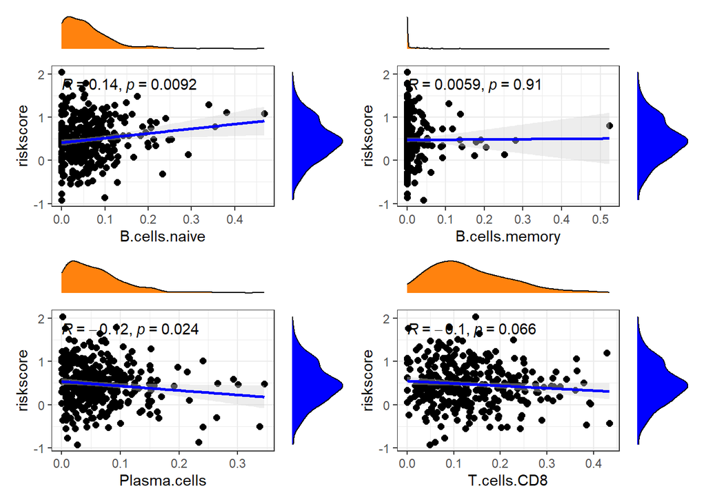

```r
library(tinyarray)
re$riskscore = fp
colnames(re) = make.names(colnames(re))
#[1:4]是只画了前4个，改成[-ncol(re)]即画全部
plots = lapply(colnames(re)[1:4],function(x){
  corscatterplot(re,x,"riskscore")
})
library(patchwork)
wrap_plots(plots)
```

#### 4.2 免疫细胞与模型基因之间的相关性

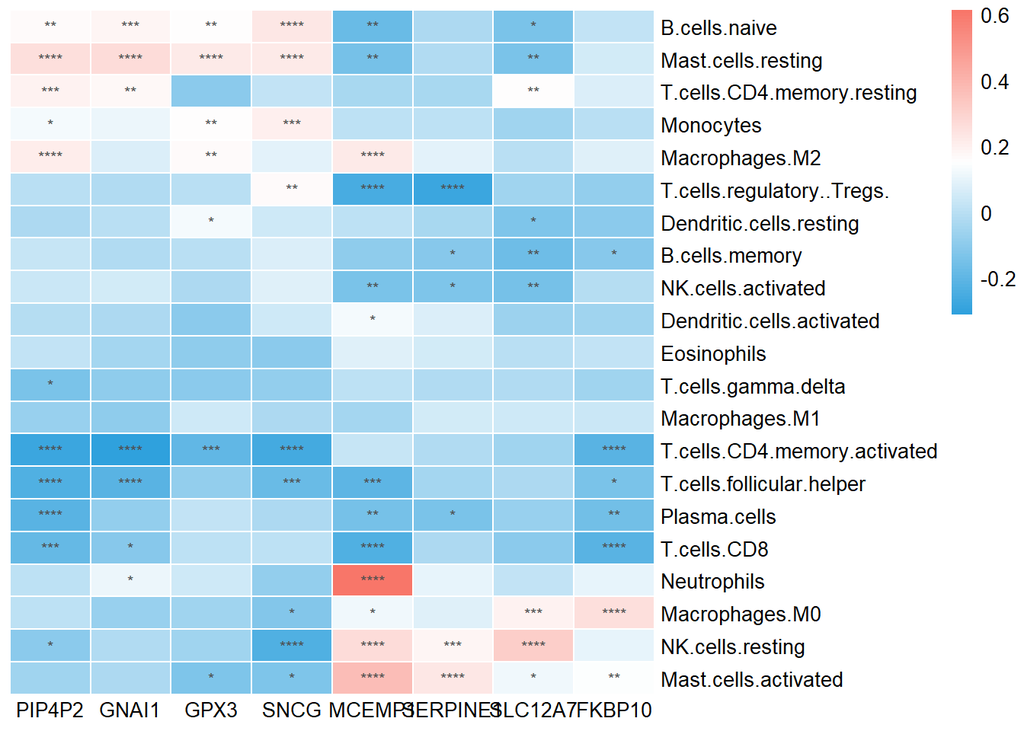

```r
gs = names(model$coefficients)
dat = rbind(t(re),exprSet[gs,])
corheatmap(dat,gs,colnames(re)[1:21])
```